# ABM_orchest

2026-04-02

`{r-setup, include=FALSE} knitr::opts_chunk$set(echo = TRUE, warning = FALSE, message = FALSE, fig.width = 15, fig.height = 10)`

# Preface

- this document considers two different versions of lhs data – one with 100 fixed cycles (designated as **v1**) – the other with dynamic convergence (convergence_threshold at 0.01) which is designated as **v2**
- Further all of the data displayed below is only considering M (mixed) debates which constitute a mix of pro and anti reduction agents (a future version to be run next week - form 25/5/26 onwards will introduce better segmentation and cross comparison of H and M debates)
- All analyses where data is not labelled in **v1** or **v2** is run with **v1** (which biases the interpretation as each debate is forced to run until it reaches 100 cycles)
- use_distinct_agents: **TRUE** (each agent has the same base parameter value but has a standard deviation associated with each parameter) / **FALSE** (all agents in that debate have the same parameter value -> assumes agents are all the same)

```r
# df comparison test
lhs_outputs$results$comparisons$empirical
```

```
## # A tibble: 3 × 8
##   condition  mean_change_t0_t1 sd_change_t0_t1 mean_change_t1_t2 sd_change_t1_t2
##   <chr>                  <dbl>           <dbl>             <dbl>           <dbl>
## 1 Control               0.0871           0.204            0.0423          0.113
## 2 Heterogen…            0.0988           0.206            0.0370          0.0954
## 3 Homogeneo…            0.167            0.196           -0.0257          0.127
## # ℹ 3 more variables: mean_change_t0_t2 <dbl>, sd_change_t0_t2 <dbl>, n <int>
```

```r
# cohens d check
lhs_outputs$results$comparisons$empirical_cohen
```

```
## # A tibble: 2 × 6
##   term          estimate std_estimate std.error statistic   p.value
##   <chr>            <dbl>        <dbl>     <dbl>     <dbl>     <dbl>
## 1 (Intercept)    0.0401       NA         0.0100     4.00  0.0000935
## 2 pro_reduction -0.00646      -0.0339    0.0144    -0.448 0.655
```

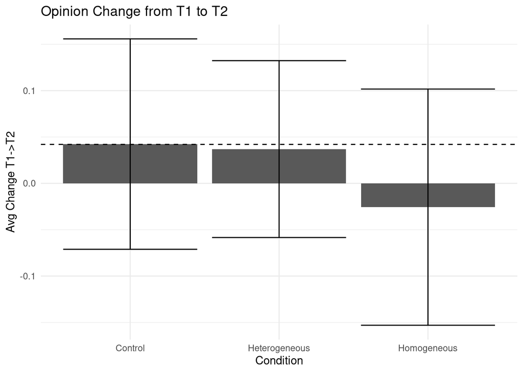

```r
# plot of empirical distribution
## needs to add labs/for title and axes and theme
lhs_outputs$plots$empirical_col()
```

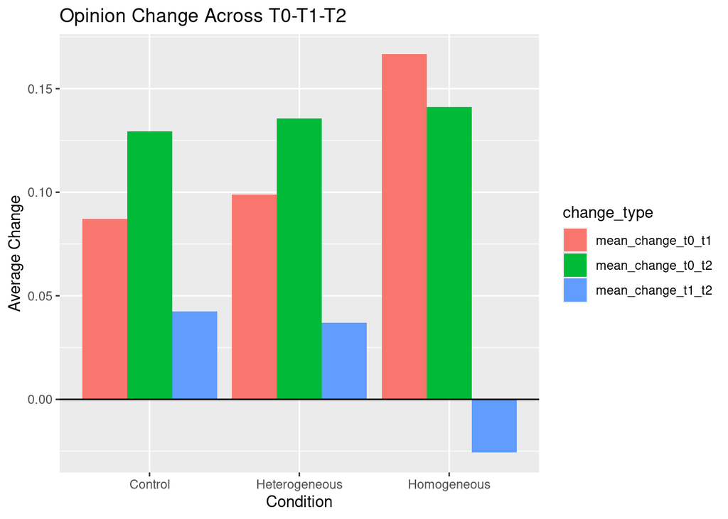

```r
# cross time col plot
lhs_outputs$plots$empirical_cross()
```

# Empirical data discovery

## Empirical Cross comparisons

- primary attitude change (8-17% of scale range) occurred between t0-t1 (sd almost twice the size of the mean change)
- mean attitude change from t1->t2 is around 3-4% (with the exception of homogeneous which sways in the negative direction) left for simulation during debate (statistically indistinguishable from spontaneous drift in control)

## Linear Regression for Cohen’s D

- std estimate represents cohen’s d –> (-0.034, p value = 0.655), no significance of population on mean change from t1->t2

## Opinion Change T1 to T2

- small positive change in heterogeneous group / slight negative change in homogeneous group -> could be due to it being all anti_reduction so they create echo chambers leaning in the wrong direction (further away from pro_reduction of meat consumption)

## Combined Bar Chart

- Represents mean change across 3 time periods
- change from t1 -> t2 is minimal –> weak empirical signal with insignificant cohen’s d implies difficulty in simulating opinion change given that it is assumed that deliberation creates social influence in this experiment

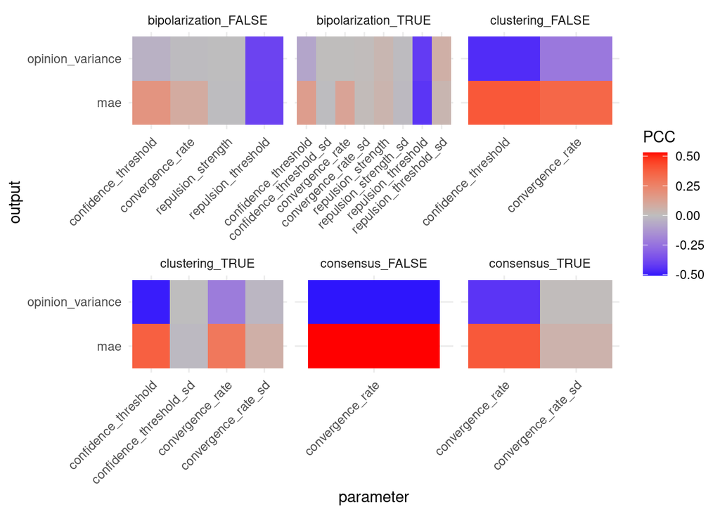

```r
# lhs_analysis comparison - v1 (threshold = 0.001), v2 (threshold = 0.01)

# PCC and PRCC using v2 as df_lhs (combined in lhs_ouputs list)
lhs_outputs$plots$pcc()
```

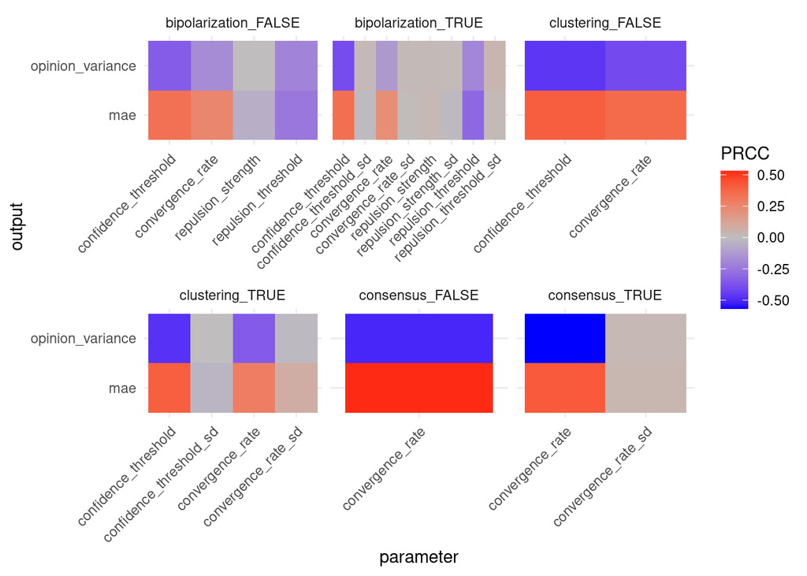

```r
lhs_outputs$plots$prcc()
```

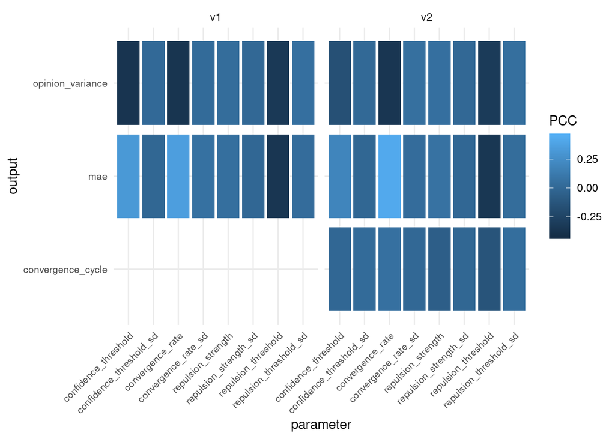

```r
# combined visualization
lhs_outputs$plots$pcc_all()
```

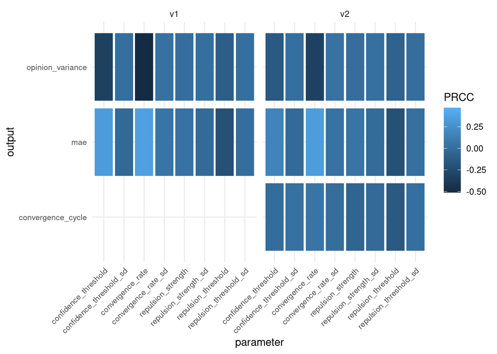

```r
lhs_outputs$plots$prcc_all()
```

```r
# include comparison plots and use df_versions
#df_versions <- lhs_outputs$inputs$versions

# interpretation:
# model structure dominates behavior (so threshold is a second-order effect)
# bipolarizaito is the only regime with meaningful sensitivity

# comparison summary
#lhs_outputs$comparisons$summary()

# convergence plot
#lhs_outputs$plots$convergence()
```

# PCC and PRCC (Pearson (Partial) Correlation Coefficients)

## PRCC for combined versions

```
## Ignoring unknown labels:
## • Title : "Model Performance by Version"
```

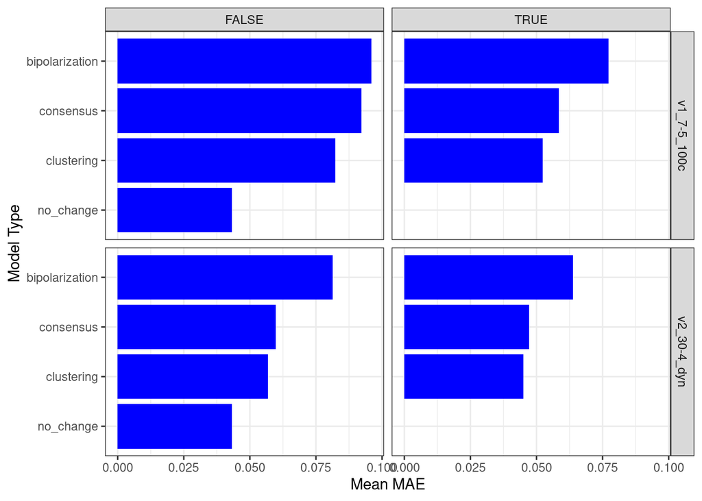

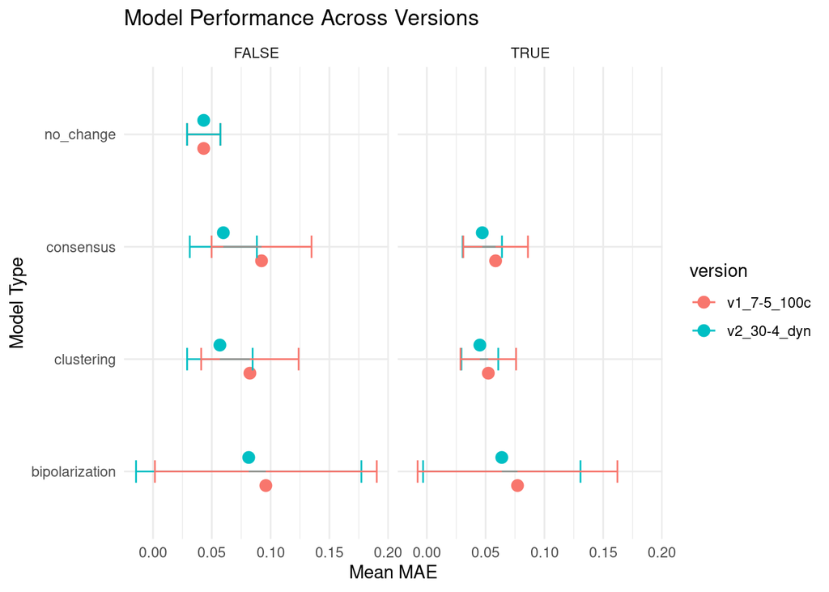

```
## Ignoring unknown labels:
## • Title : "Performance Gap to Best Model"
```

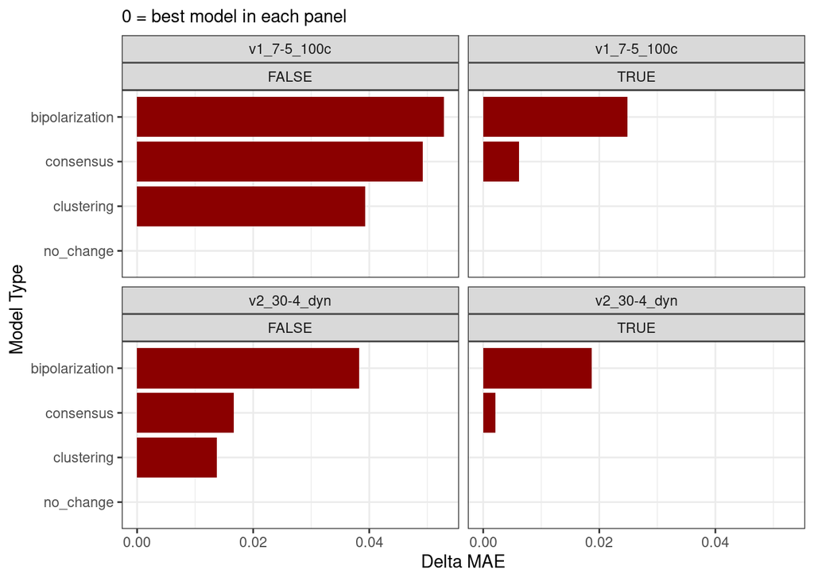

```
## # A tibble: 30 × 8
##    selected_debate_id abm_mae debate_label.x pct_hetero debate_label.y ols_mae
##    <chr>                <dbl> <chr>               <dbl> <chr>            <dbl>
##  1 14                  0.0780 M1                  0.613 M1              0.0170
##  2 15                  0.100  M10                 0.621 M10             0.0466
##  3 16                  0.0542 M12                 0.619 M12             0.0567
##  4 17                  0.153  M13                 0.619 M13             0.0329
##  5 18                  0.0558 M14                 0.610 M14             0.0322
##  6 19                  0.0954 M15                 0.626 M15             0.0322
##  7 20                  0.0988 M16                 0.618 M16             0.0498
##  8 21                  0.0675 M18                 0.617 M18             0.0365
##  9 22                  0.128  M2                  0.620 M2              0.0429
## 10 23                  0.0772 M20                 0.610 M20             0.0337
## # ℹ 20 more rows
## # ℹ 2 more variables: delta_mae <dbl>, abm_better <lgl>
```

```
## # A tibble: 14 × 5
##    model_type     version     speaking_mode mae_mean mae_sd
##    <chr>          <chr>       <lgl>            <dbl>  <dbl>
##  1 no_change      v1_7-5_100c FALSE           0.0431 0.0142
##  2 no_change      v2_30-4_dyn FALSE           0.0431 0.0142
##  3 clustering     v2_30-4_dyn TRUE            0.0451 0.0157
##  4 consensus      v2_30-4_dyn TRUE            0.0472 0.0167
##  5 clustering     v1_7-5_100c TRUE            0.0523 0.0236
##  6 clustering     v2_30-4_dyn FALSE           0.0569 0.0279
##  7 consensus      v1_7-5_100c TRUE            0.0585 0.0275
##  8 consensus      v2_30-4_dyn FALSE           0.0598 0.0285
##  9 bipolarization v2_30-4_dyn TRUE            0.0638 0.0669
## 10 bipolarization v1_7-5_100c TRUE            0.0771 0.0849
## 11 bipolarization v2_30-4_dyn FALSE           0.0814 0.0958
## 12 clustering     v1_7-5_100c FALSE           0.0824 0.0414
## 13 consensus      v1_7-5_100c FALSE           0.0923 0.0425
## 14 bipolarization v1_7-5_100c FALSE           0.0959 0.0943
```

# Model Performance Comparisons

## MAE by model type and version bar chart

- **FALSE** & **TRUE** labels denote speaking mode (exposure driven influence)
- Dynamic convergence systematically outperforms fixed cycle implementation across all conditions
- None of the models in speaking mode TRUE/FALSE has a lower mean MAE than the no_change condition (agents are initiated and do nothing –> no change)

## Model Performance Across Versions

- Reasonably large overlap in error bars for bipolarization across both versions, however mean mae is lower in the speaking mode (TRUE) condition –> speaking_mode does have a positive impact on reducing mean mae

## MAE by model type and version bar chart (RED)

- **FALSE** & **TRUE** labels denote speaking mode (exposure driven influence)
- here the “best” model is the lowest mae model in that panel (e.g., consensus, clustering, no_change, bipolarization)
- clustering consistently has the smallest delta (best performance compared with no_change)
- dynamic convergence outperforms fixed cycles in all conditions
- CAVEAT: pre-GA unoptimized lhs values, rankings may shift after GA runs

## ABM vs OLS comparison table

- Only the instance of Mixed debate 12 outperforms the ols mae (taken as a baseline)
- As only mixed debates appear in this table it can be assumed that they are for a large part heterogeneous (i.e. composed of pro and anti consumption reductiona agents)
- Delta_mae: positive (abm is worse), negative (abm is better)

## Model type comparison with no_change

- No model beats the no_change mean_mae (we still ahve slightly too much error but the dynamic converging **v2** seems to come close under clustering and consensus models with speaking mode)
- Worst two models are consensus and bipolarization in the **v1** with 100 fixed cycles

```
## # A tibble: 13 × 7
##    debate_composition model_type     speaking_mode use_distinct_agents mae_mean
##    <chr>              <chr>          <lgl>         <lgl>                  <dbl>
##  1 M                  bipolarization FALSE         FALSE                 0.107
##  2 M                  bipolarization FALSE         TRUE                  0.113
##  3 M                  bipolarization TRUE          FALSE                 0.0848
##  4 M                  bipolarization TRUE          TRUE                  0.0887
##  5 M                  clustering     FALSE         FALSE                 0.0868
##  6 M                  clustering     FALSE         TRUE                  0.0951
##  7 M                  clustering     TRUE          FALSE                 0.0517
##  8 M                  clustering     TRUE          TRUE                  0.0534
##  9 M                  consensus      FALSE         FALSE                 0.100
## 10 M                  consensus      FALSE         TRUE                  0.110
## 11 M                  consensus      TRUE          FALSE                 0.0596
## 12 M                  consensus      TRUE          TRUE                  0.0629
## 13 M                  no_change      FALSE         FALSE                 0.0399
## # ℹ 2 more variables: mae_sd <dbl>, n <int>
```

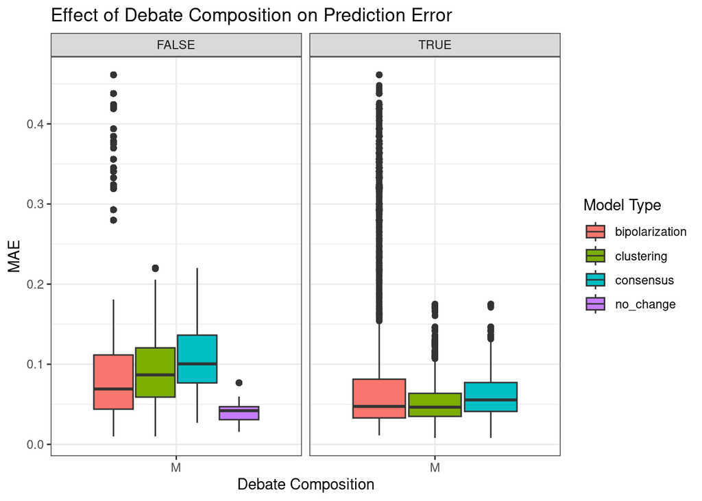

```
## # A tibble: 13 × 8
##    speaking_mode debate_composition model_type     use_distinct_agents mae_mean
##    <lgl>         <chr>              <chr>          <lgl>                  <dbl>
##  1 FALSE         M                  bipolarization FALSE                 0.107
##  2 FALSE         M                  bipolarization TRUE                  0.113
##  3 FALSE         M                  clustering     FALSE                 0.0868
##  4 FALSE         M                  clustering     TRUE                  0.0951
##  5 FALSE         M                  consensus      FALSE                 0.100
##  6 FALSE         M                  consensus      TRUE                  0.110
##  7 FALSE         M                  no_change      FALSE                 0.0399
##  8 TRUE          M                  bipolarization FALSE                 0.0848
##  9 TRUE          M                  bipolarization TRUE                  0.0887
## 10 TRUE          M                  clustering     FALSE                 0.0517
## 11 TRUE          M                  clustering     TRUE                  0.0534
## 12 TRUE          M                  consensus      FALSE                 0.0596
## 13 TRUE          M                  consensus      TRUE                  0.0629
## # ℹ 3 more variables: mae_sd <dbl>, mean_norm_convergence <dbl>, n <int>
```

# Behavioral Effects

## Debate Composition on Mean MAE (table)

- Biased because data is filtered by Mixed debates
- No_change with speaking_mode ( **FALSE** still outperforms all other models)
- Consensus with speaking_mode ( **TRUE** ) and distinct_agents ( **FALSE** and **TRUE** ) shows some promise

## Speaking Mode and Debate Composition on MAE impact

- Speaking mode **TRUE** globally has a lower mean mae than **FALSE** but does not beat no_change
- n column: represents the amount of interactions (broadcasts) that occur (for reference: one interaction could be agent 1 speaking with agents 2,3,4,5 in one cycle) - the number here is slightly inflated due to the nature of how these interactions are collected and the fact there are multiple interactions in one cycle (i.e. one agent broadcasts to multiple others)

```
## # A tibble: 5 × 4
##   model_type     current_condition outcome          n
##   <chr>          <chr>             <chr>        <int>
## 1 bipolarization heterogeneous     Convergence  16882
## 2 bipolarization heterogeneous     Polarization  2648
## 3 clustering     heterogeneous     Convergence  11170
## 4 consensus      heterogeneous     Convergence   6980
## 5 no_change      heterogeneous     Convergence    700
```

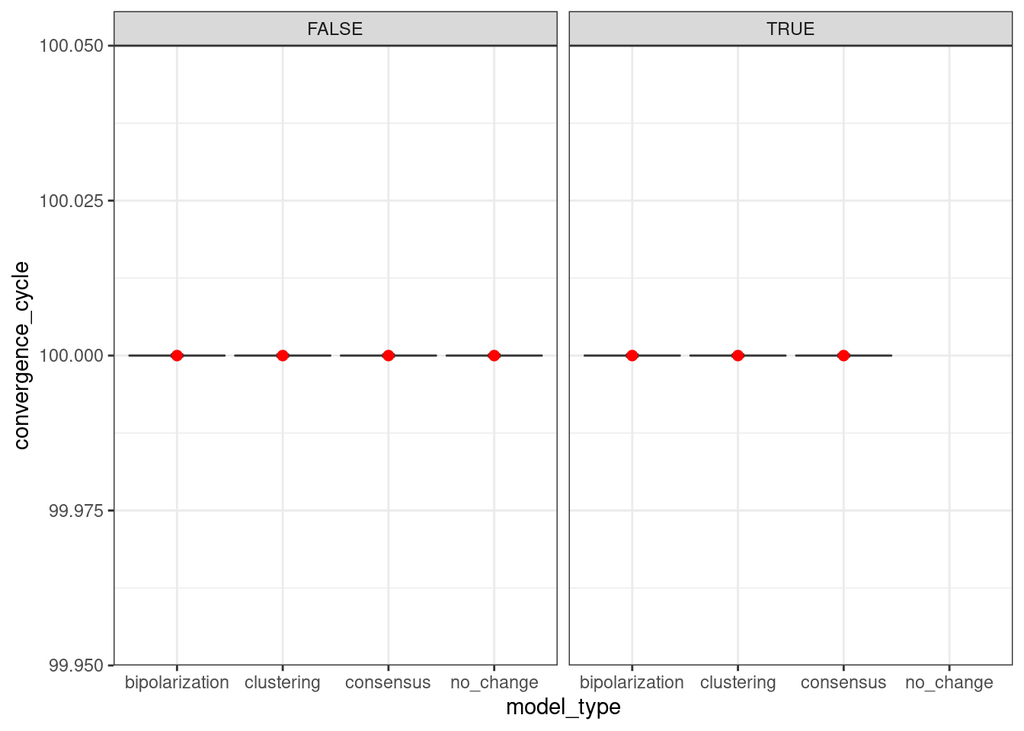

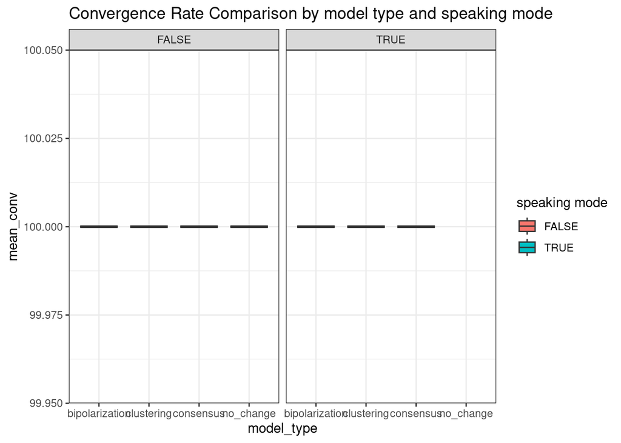

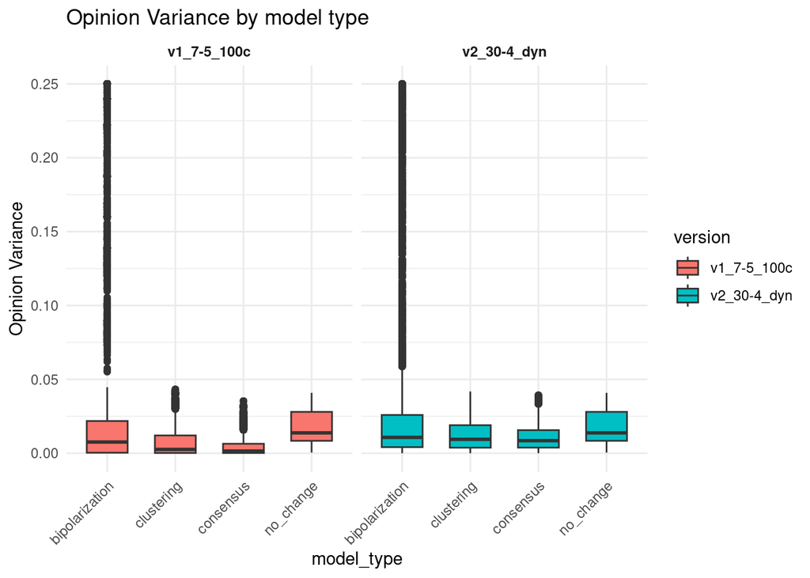

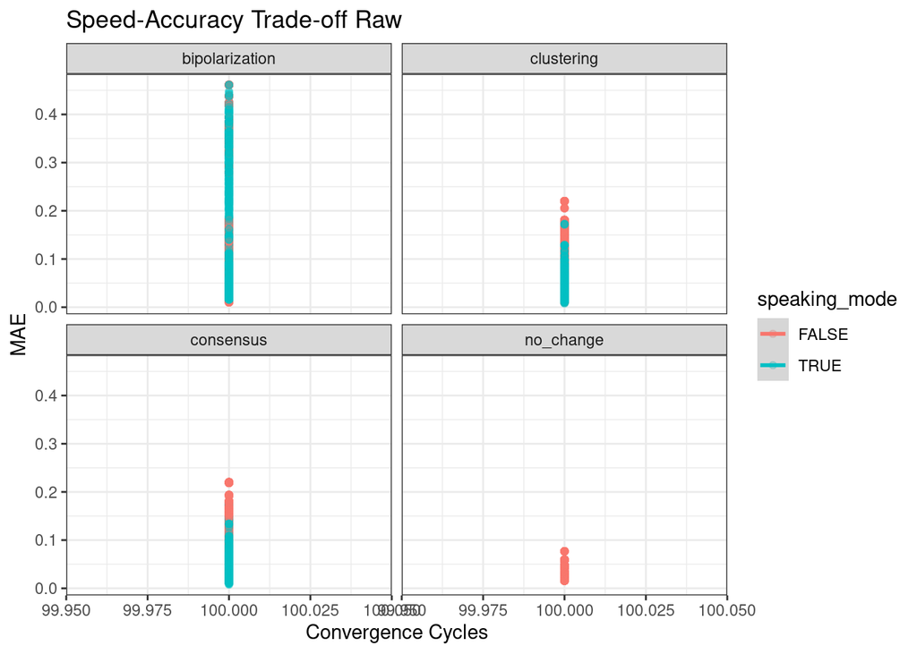

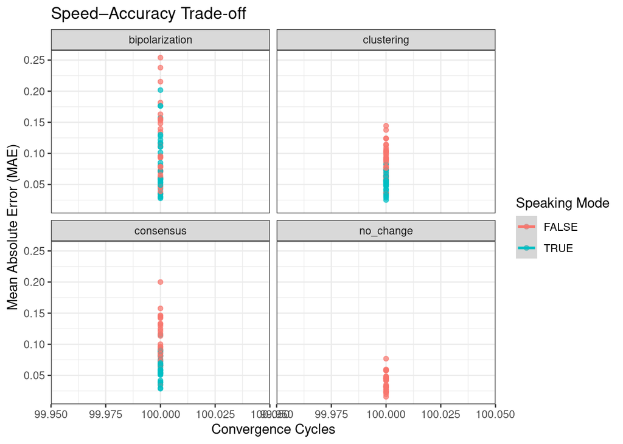

# Convergence Analysis - (the first two and last two plots do not highlight any major findings given the fixed cycles)

## Model Type and Convergence

- All models besides bipolarization result in convergence with clustering and bipolarization having the largest number of interactions

## Opinion Variance by Model Type

- Bipolarization in both versions has a very large tale of variance which can be associated with the nature of bipolarization dynamics
- The variance in the fixed cycles model has a slight tendency (visually) of being lower than those in the dynamic convergence and both have less variance than no_change (which I cannot explain, could be due to natural variance in the empirical input data [Thomas CSV] used to initiate each simulated debate)

```
## # A tibble: 7 × 6
##   model_type     use_distinct_agents mae_mean mae_median mae_sd     n
##   <chr>          <lgl>                  <dbl>      <dbl>  <dbl> <int>
## 1 bipolarization FALSE                 0.0961     0.0571 0.103   6980
## 2 bipolarization TRUE                  0.101      0.0593 0.104  12550
## 3 clustering     FALSE                 0.0693     0.0592 0.0400  4190
## 4 clustering     TRUE                  0.0743     0.0639 0.0415  6980
## 5 consensus      FALSE                 0.0800     0.0720 0.0428  2790
## 6 consensus      TRUE                  0.0862     0.0794 0.0420  4190
## 7 no_change      FALSE                 0.0399     0.0421 0.0140   700
```

# Robustness

## Using Distinct Agents

- across all three models (excluding no_change) introducing distinct agents increases the mae compared with non_distinct agents
- caveat is that the samples sizes are large with **TRUE**, makes sense given it is a binary parameter with unequal representation in latin hypercube sampling

| mean_correct | mean_mae | mean_baseline |
| --- | --- | --- |
| 0.5206984 | 0.06225377 | 0.04329659 |

```
## # A tibble: 28 × 6
##    version     model_type    speaking_mode debate_composition mae_mean conv_mean
##    <chr>       <chr>         <lgl>         <chr>                 <dbl>     <dbl>
##  1 v1_7-5_100c bipolarizati… FALSE         H                    0.0593       100
##  2 v1_7-5_100c bipolarizati… FALSE         M                    0.111        100
##  3 v1_7-5_100c bipolarizati… TRUE          H                    0.0528       100
##  4 v1_7-5_100c bipolarizati… TRUE          M                    0.0873       100
##  5 v1_7-5_100c clustering    FALSE         H                    0.0593       100
##  6 v1_7-5_100c clustering    FALSE         M                    0.0920       100
##  7 v1_7-5_100c clustering    TRUE          H                    0.0511       100
##  8 v1_7-5_100c clustering    TRUE          M                    0.0528       100
##  9 v1_7-5_100c consensus     FALSE         H                    0.0597       100
## 10 v1_7-5_100c consensus     FALSE         M                    0.106        100
## # ℹ 18 more rows
```

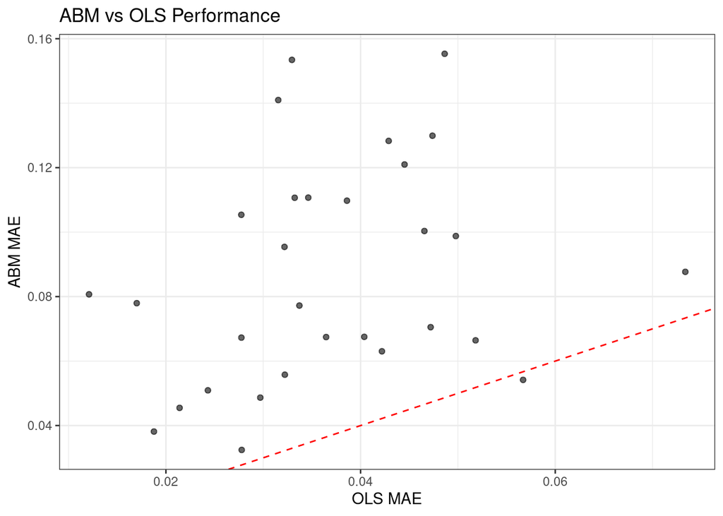

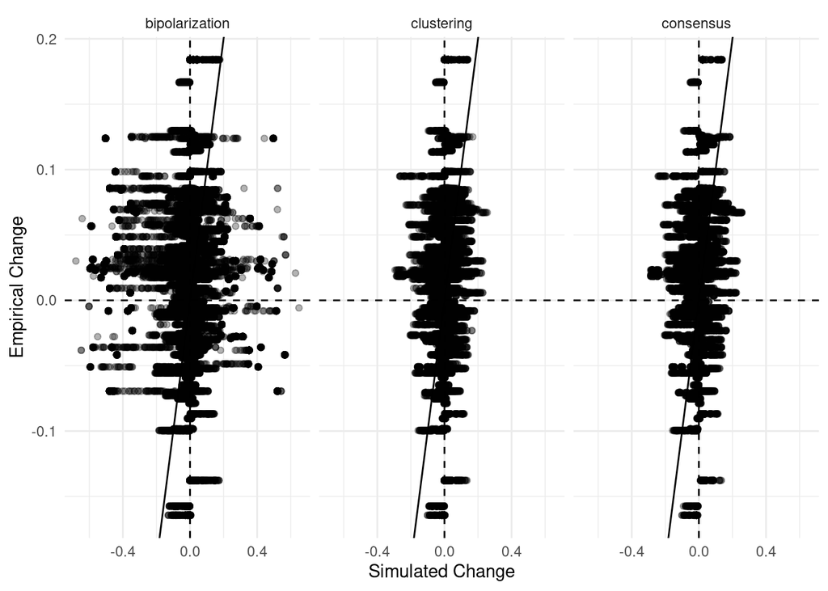

| model_type | current_condition | selected_debate_id | pct_correct_dir | pct_wrong_dir | mean_mae | mean_baseline_mae | n | mae_improvement |
| --- | --- | --- | --- | --- | --- | --- | --- | --- |
| clustering | heterogeneous | 33 | 0.6805556 | 0.6805556 | 0.02517011 | 0.01967593 | 720 | -0.0054941863 |
| bipolarization | heterogeneous | 33 | 0.5769841 | 0.5817460 | 0.02785224 | 0.01967593 | 1,260 | -0.0081763163 |
| consensus | heterogeneous | 25 | 0.8500000 | 0.9000000 | 0.02860260 | 0.03153935 | 460 | 0.0029367543 |
| clustering | heterogeneous | 25 | 0.8081081 | 0.8743243 | 0.02878033 | 0.03153935 | 740 | 0.0027590219 |
| bipolarization | heterogeneous | 34 | 0.3300000 | 0.6453846 | 0.02955566 | 0.02343750 | 1,300 | -0.0061181595 |
| consensus | heterogeneous | 33 | 0.7500000 | 0.7500000 | 0.02966217 | 0.01967593 | 460 | -0.0099862395 |
| bipolarization | heterogeneous | 25 | 0.7111111 | 0.8119048 | 0.03065518 | 0.03153935 | 1,260 | 0.0008841713 |
| clustering | heterogeneous | 29 | 0.4738739 | 0.9414414 | 0.03132111 | 0.02681327 | 1,110 | -0.0045078364 |
| clustering | heterogeneous | 32 | 0.7297297 | 0.7297297 | 0.03368259 | 0.02353395 | 555 | -0.0101486356 |
| bipolarization | heterogeneous | 32 | 0.5882353 | 0.5882353 | 0.03443569 | 0.02353395 | 1,020 | -0.0109017345 |

# interpretation

## Overall

# ABM vs OLS Performance

- biased because we are only showing the results of **v1**
- significantly worse (than the ols which is the baseline), forcing the debates to run the full 100 cycles introduces nosie that can degrade predictive accuracry

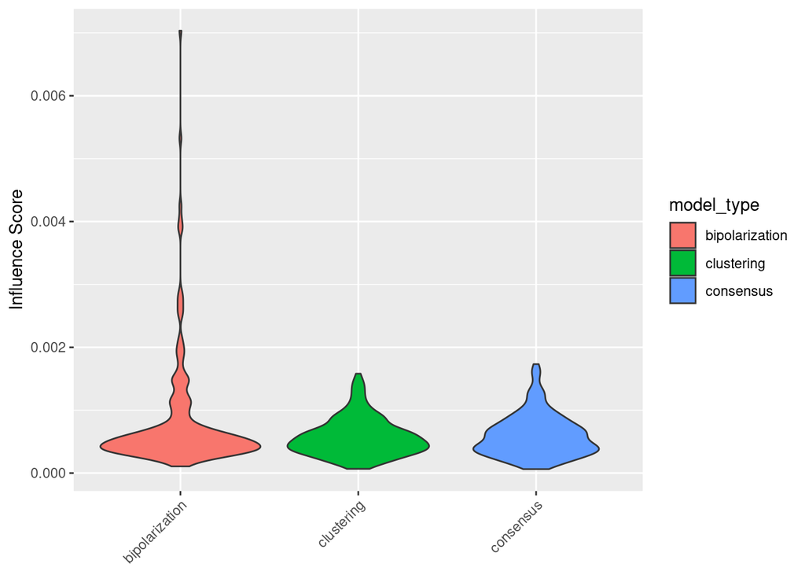

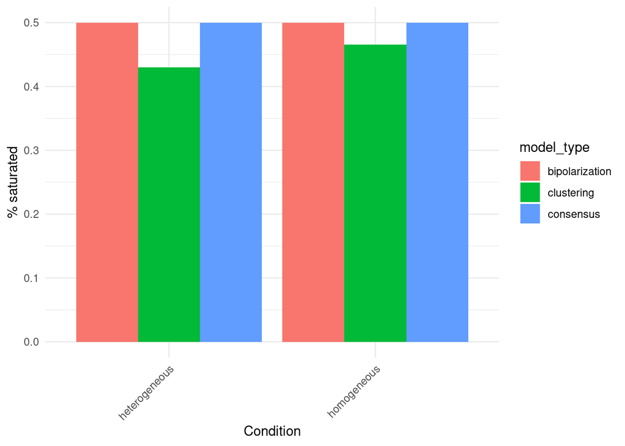

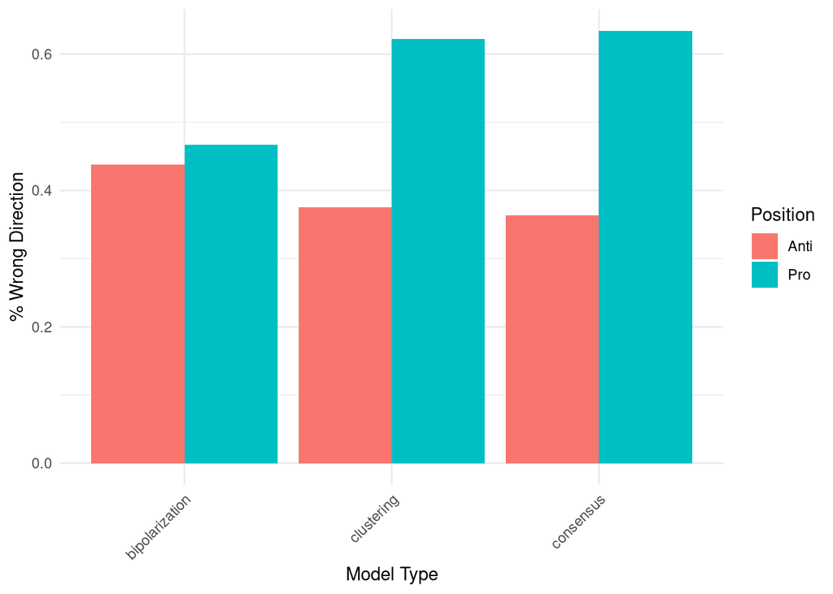

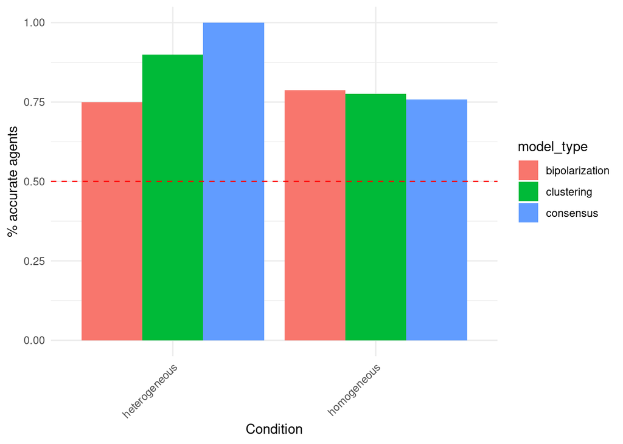

| model_type | current_condition | selected_debate_id | sender_id | influence_score | n_broadcasts | efficiency (×10⁻⁴) |
| --- | --- | --- | --- | --- | --- | --- |
| bipolarization | heterogeneous | 41 | 34 | 0.007035148 | 30,240 | 0.0023264378 |
| bipolarization | heterogeneous | 38 | 18 | 0.005324016 | 26,970 | 0.0019740513 |
| bipolarization | heterogeneous | 17 | 70 | 0.004258436 | 31,620 | 0.0013467539 |
| bipolarization | heterogeneous | 22 | 8 | 0.004049889 | 27,040 | 0.0014977401 |
| bipolarization | heterogeneous | 15 | 61 | 0.003907848 | 27,872 | 0.0014020696 |
| bipolarization | heterogeneous | 39 | 26 | 0.003881852 | 27,540 | 0.0014095322 |
| bipolarization | heterogeneous | 30 | 148 | 0.002883116 | 24,552 | 0.0011742895 |
| bipolarization | heterogeneous | 17 | 69 | 0.002792549 | 28,560 | 0.0009777834 |
| bipolarization | heterogeneous | 17 | 74 | 0.002734834 | 27,200 | 0.0010054538 |
| bipolarization | heterogeneous | 38 | 16 | 0.002636229 | 26,040 | 0.0010123767 |

| model_type | sender_is_pro | mean_delta |
| --- | --- | --- |
| bipolarization | false | 0.0004798749 |
| bipolarization | true | 0.0011058220 |
| clustering | false | 0.0003165719 |
| clustering | true | 0.0006418989 |
| consensus | false | 0.0003047384 |
| consensus | true | 0.0006981515 |

# interpretation

# pro interpretation

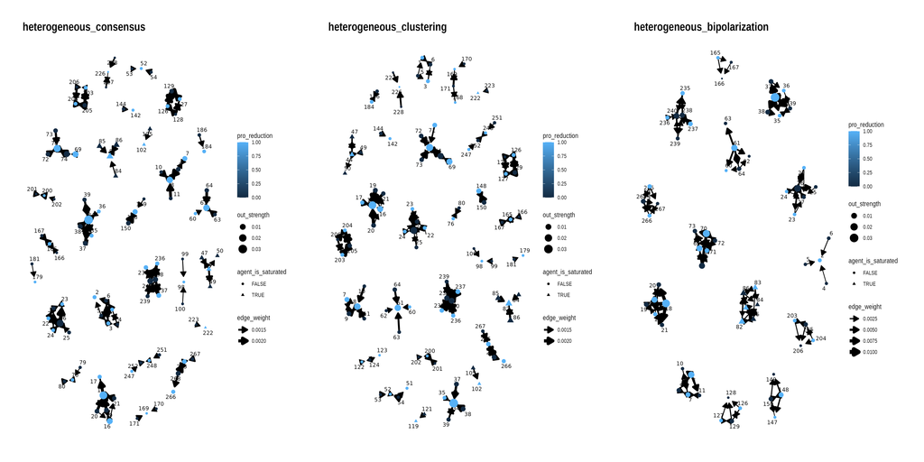

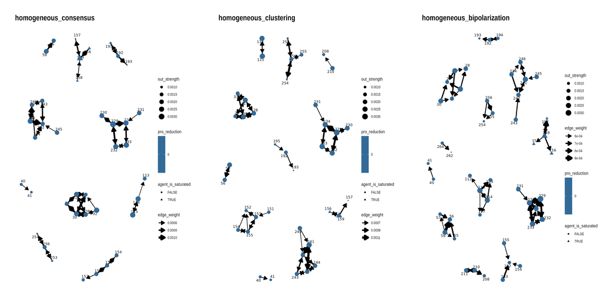

## Homogeneous plot (homogeneous debates, only anti reduction agents)

- all agents are anti-reduction
- network structure is relatively sparse and linear (chains of influence)
- opinions in homogeneous groups operate through sequential cascades rather than reinforcing loops

## Heterogeneous plot (heterogeneous debates, both pro and anti agents)

```
## # A tibble: 1 × 1
##   accuracy
##      <dbl>
## 1      0.5
```

## debate classifier

- LHS results suggest that initial variance plays a significant role in the predictor of model suitability.
- one could use a preliminary classifier for GA runs to check which model would work “best” for a specific debate
- debates with var < 0.01 are predicted to favor consensus, dynamics while high-variance favor bipolarization

– next stage set-up - could classify debate by initial variance, then apply GA optimization for that predicted model - preliminary classifier is too simple, variance is not the only predictor

```
## # A tibble: 6 × 29
##   model_type use_distinct_agents cr_min cr_max cr_max_sd cr_min_sd ct_min ct_max
##   <chr>      <lgl>                <dbl>  <dbl>     <dbl>     <dbl>  <dbl>  <dbl>
## 1 bipolariz… FALSE                0.005    0.1      0.05      0.05    0.1    0.3
## 2 bipolariz… TRUE                 0.005    0.1      0.02      0       0.1    0.3
## 3 clustering FALSE                0.005    0.1      0.05      0.05    0.1    0.6
## 4 clustering TRUE                 0.005    0.1      0.02      0       0.1    0.6
## 5 consensus  FALSE                0.005    0.1      0.05      0.05   NA     NA
## 6 consensus  TRUE                 0.005    0.1      0.02      0      NA     NA
## # ℹ 21 more variables: ct_min_sd <dbl>, ct_max_sd <dbl>, rs_min <dbl>,
## #   rs_max <dbl>, rs_min_sd <dbl>, rs_max_sd <dbl>, rt_min <dbl>, rt_max <dbl>,
## #   rt_min_sd <dbl>, rt_max_sd <dbl>, best_mae <dbl>, mae_threshold_used <dbl>,
## #   n <int>, cr_range_ok <lgl>, ct_range_ok <lgl>, rs_range_ok <lgl>,
## #   rt_range_ok <lgl>, cr_sd_range_ok <lgl>, ct_sd_range_ok <lgl>,
## #   rs_sd_range_ok <lgl>, rt_sd_range_ok <lgl>
```